# Matrix

In NumPy, a matrix is a specialized 2D array that retains its two-dimensional nature through operations. It has specific operators for matrix math, such as matrix multiplication and matrix inversion.

- Creation: A matrix in NumPy can be created using the `numpy.matrix` class, which is a subclass of `numpy.ndarray`. Matrices can be created from a string of data or any array-like object.

  ```
  A = np.matrix('1 2; 3 4')
  B = np.matrix([[1, 2], [3, 4]])
  ```

- Operations:
  - Matrix Multiplication: `*`
  - Inversion: `.I`
  - Transpose: `.T`

## Create Matrix

```python
import numpy as np
```

import numpy as np

```python
print(np.mat("5 6;7 8"))
print(type(np.mat("5 6;7 8")))
print(np.mat([[5,6],[7,8]]))
print(type(np.mat([[5,6],[7,8]])))
print(np.array([[5,6],[7,8]]))
print(type(np.array([[5,6],[7,8]])))
```

print(np.mat("5 6;7 8")) print(type(np.mat("5 6;7 8"))) print(np.mat([[5,6],[7,8]])) print(type(np.mat([[5,6],[7,8]]))) print(np.array([[5,6],[7,8]])) print(type(np.array([[5,6],[7,8]])))

```
[[5 6]
 [7 8]]
<class 'numpy.matrix'>
[[5 6]
 [7 8]]
<class 'numpy.matrix'>
[[5 6]
 [7 8]]
<class 'numpy.ndarray'>
```

```python
np.mat(np.zeros((3,3)))
```

np.mat(np.zeros((3,3)))

```
matrix([[0., 0., 0.],
        [0., 0., 0.],
        [0., 0., 0.]])
```

```python
np.matrix(np.ones((2,4)))
```

np.matrix(np.ones((2,4)))

```
matrix([[1., 1., 1., 1.],
        [1., 1., 1., 1.]])
```

```python
np.matrix(np.random.randn(3,3))
```

np.matrix(np.random.randn(3,3))

```
matrix([[ 0.20541112,  1.06524902, -0.3571914 ],
        [ 0.01174502,  0.86889312, -0.08787096],
        [ 0.37034351, -1.33600316, -0.16127082]])
```

```python
np.matrix(np.random.randint(1,8,size = (3,3)))
```

np.matrix(np.random.randint(1,8,size = (3,3)))

```
matrix([[7, 2, 6],
        [2, 7, 3],
        [1, 5, 4]])
```

```python
np.eye(3,3)
```

np.eye(3,3)

```
array([[1., 0., 0.],
       [0., 1., 0.],
       [0., 0., 1.]])
```

```python
np.diag([1,2,3])
```

np.diag([1,2,3])

```
array([[1, 0, 0],
       [0, 2, 0],
       [0, 0, 3]])
```

## Operation in Matrix

```python
d1 = np.mat(np.arange(6).reshape((3,2)))
d2 = np.mat([1,2])
print(d1)
print(d2)
d1 + d2, d1 - d2
```

d1 = np.mat(np.arange(6).reshape((3,2))) d2 = np.mat([1,2]) print(d1) print(d2) d1 + d2, d1 - d2

```
[[0 1]
 [2 3]
 [4 5]]
[[1 2]]
```

```
(matrix([[1, 3],
         [3, 5],
         [5, 7]]),
 matrix([[-1, -1],
         [ 1,  1],
         [ 3,  3]]))
```

```python
d1 / d2
```

d1 / d2

```
matrix([[0. , 0.5],
        [2. , 1.5],
        [4. , 2.5]])
```

```python
d1 * d2.T
```

d1 * d2.T

```
matrix([[ 2],
        [ 8],
        [14]])
```

```python
print(d1)
print(d2)
np.multiply(d1,d2)
```

print(d1) print(d2) np.multiply(d1,d2)

```
[[0 1]
 [2 3]
 [4 5]]
[[1 2]]
```

```
matrix([[ 0,  2],
        [ 2,  6],
        [ 4, 10]])
```

```python
### List multiplication and dot product

n1 = np.array([[1,2],[5,6],[9,10]])
n2 = np.array([1,2])

print(n1*n2)
print(n1.dot(n2))
```

### List multiplication and dot product n1 = np.array([[1,2],[5,6],[9,10]]) n2 = np.array([1,2]) print(n1*n2) print(n1.dot(n2))

```
[[ 1  4]
 [ 5 12]
 [ 9 20]]
[ 5 17 29]
```

```python
print(d1)
print(d1.I)
```

print(d1) print(d1.I)

```
[[0 1]
 [2 3]
 [4 5]]
[[-1.08333333 -0.33333333  0.41666667]
 [ 0.83333333  0.33333333 -0.16666667]]
```

### Common function in NumPy

- `add()`,`subtract()`,`multiply()`,`divide()`
- `abs()`,`sqrt()`,`square()`
- `log()`,`log10()`,`log2()`
- `reciprocal()`
- `power()`,`mod()`,`exp()`
- `around()`,`ceil()`,`floor()`
- `sin()`,`cos()`,`tan()`
- `modf()`: It takes an input array and returns two arrays - the first one containing the fractional part and the second one containing the integral part of the elements in the input array.

  ```
  arr = np.array([3.5, -2.3, 7.9])
  fractional_part, integral_part = np.modf(arr)
  ```

- `sign()`: For each element in the input array, `sign` returns 1 if the element is positive, 0 if it's zero, and -1 if it's negative.

  ```
  arr = np.array([-1, 0, 1, 2])
  sign_arr = np.sign(arr)
  ```

```python
d2 = np.array([1.,2.])
print(d2)
print(np.reciprocal(d2))
```

d2 = np.array([1.,2.]) print(d2) print(np.reciprocal(d2))

```
[1. 2.]
[1.  0.5]
```

```python
np.power(d2,np.array([1,2]))
```

np.power(d2,np.array([1,2]))

```
array([1., 4.])
```

```python
np.mod(d2,np.array([1,1]))
```

np.mod(d2,np.array([1,1]))

```
array([0., 0.])
```

```python
n = np.array([1.55,68.23,157.65,-15.3,-5.8])
print(n)
print(np.around(n,decimals=-1))
```

n = np.array([1.55,68.23,157.65,-15.3,-5.8]) print(n) print(np.around(n,decimals=-1))

```
[  1.55  68.23 157.65 -15.3   -5.8 ]
[  0.  70. 160. -20. -10.]
```

```python
arr = np.array([3.5, -2.3, 7.9])
fractional_part, integral_part = np.modf(arr)
fractional_part, integral_part
```

arr = np.array([3.5, -2.3, 7.9]) fractional_part, integral_part = np.modf(arr) fractional_part, integral_part

```
(array([ 0.5, -0.3,  0.9]), array([ 3., -2.,  7.]))
```

```python
arr = np.array([-1, 0, 1, 2])
sign_arr = np.sign(arr)
sign_arr
```

arr = np.array([-1, 0, 1, 2]) sign_arr = np.sign(arr) sign_arr

```
array([-1,  0,  1,  1])
```

### Statistical function in NumPy

- `sum()`
- `cumsum()`,`cumprod()`
- `mean()`,`min()`,`max()`, `median()`,`var()`,`std()`
- `average()`: is used to compute the weighted average of elements in an array.
  - Basic Usage:

  ```
  data = np.array([1, 2, 3, 4, 5])
  avg = np.average(data)
  ```

  - Weighted Average:

  ```
  weights = np.array([1, 2, 3, 4, 5])
  weighted_avg = np.average(data, weights=weights)
  ```

  - Axis Argument:

  ```
  data_2d = np.array([[1, 2], [3, 4]])
  avg_col = np.average(data_2d, axis=0)  # Average across columns
  avg_row = np.average(data_2d, axis=1)  # Average across rows
  ```

```python
n = np.array([[1,2,3],[4,5,6],[7,8,9]])
n.sum(axis=0),n.sum(axis=1)
```

n = np.array([[1,2,3],[4,5,6],[7,8,9]]) n.sum(axis=0),n.sum(axis=1)

```
(array([12, 15, 18]), array([ 6, 15, 24]))
```

```python
print(n.cumprod(axis=1))
print(n.cumprod(axis=0))
```

print(n.cumprod(axis=1)) print(n.cumprod(axis=0))

```
[[  1   2   6]
 [  4  20 120]
 [  7  56 504]]
[[  1   2   3]
 [  4  10  18]
 [ 28  80 162]]
```

### Sort in NumPy

- `sort()`
- `argsort()`: is used to sort an array or data along a specific axis, returning the indices that would sort the array.

  ```
  x = np.array([3, 1, 2])
  indices = np.argsort(x)
  ```

  Here, indices will be `[1, 2, 0]`, indicating the sorted order of elements in `x`.
- `lexsort()`: is used for indirect lexicographical sorting based on multiple keys.

  ```
  a = np.array([1, 2, 1, 2])
  b = np.array([0, 0, 1, 1])
  indices = np.lexsort((b, a))
  ```

  In this example, the array is first sorted by `a`, then by `b`. So, indices will be `[0, 2, 1, 3]`.

```python
n = np.array([[4,7,3],[2,8,5],[9,1,6]])
np.sort(n)
```

n = np.array([[4,7,3],[2,8,5],[9,1,6]]) np.sort(n)

```
array([[3, 4, 7],
       [2, 5, 8],
       [1, 6, 9]])
```

```python
np.argsort(n)
```

np.argsort(n)

```
array([[2, 0, 1],
       [0, 2, 1],
       [1, 2, 0]], dtype=int64)
```

```python
math = np.array([101,109,115,108,118,118])
en = np.array([117,105,98,108,98,109])
total = np.array([621,623,620,620,615,615])
sort_total = np.lexsort((en,math,total))
print(sort_total)
```

math = np.array([101,109,115,108,118,118]) en = np.array([117,105,98,108,98,109]) total = np.array([621,623,620,620,615,615]) sort_total = np.lexsort((en,math,total)) print(sort_total)

```
[4 5 3 2 0 1]
```

```python
lst = [[total[i],math[i],en[i]] for i in sort_total]
lst
```

lst = [[total[i],math[i],en[i]] for i in sort_total] lst

```
[[615, 118, 98],
 [615, 118, 109],
 [620, 108, 108],
 [620, 115, 98],
 [621, 101, 117],
 [623, 109, 105]]
```

### Transfer Graph to Gray Scale(Example)

```python
import matplotlib.pyplot as plt
```

import matplotlib.pyplot as plt

```python
n1 = plt.imread("Data/Pink_flower.jpg")
plt.imshow(n1)
```

n1 = plt.imread("Data/Pink_flower.jpg") plt.imshow(n1)

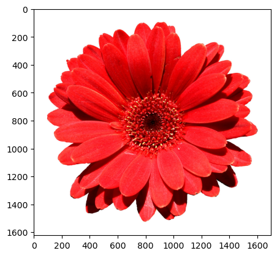

```python
n1.shape
```

n1.shape

```
(1623, 1699, 3)
```

```python
para_lst = np.array([0.299,0.587,0.144])
gray_img = np.dot(n1,para_lst)
plt.imshow(gray_img)
```

para_lst = np.array([0.299,0.587,0.144]) gray_img = np.dot(n1,para_lst) plt.imshow(gray_img)

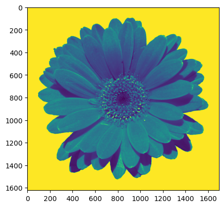